# examples_0608

### Actual question

The 50 spins were used to generate a histogram.

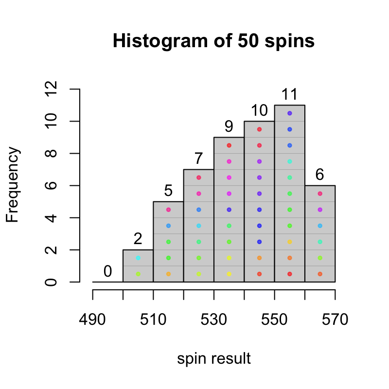

- How many spins were less than 540?
  - $\#(x<540) =$
- What proportion of spins were less than 540?
  - $\mathrm{proportion}(x<540) =$
- How many spins were more than 530?
  - $\#(x>530) =$
- What proportion of spins were more than 530?
  - $\mathrm{proportion}(x>530) =$
- How many spins were between 520 and 550?
  - $\#(520<x<550) =$
- What proportion of spins were between 520 and 550?
  - $\mathrm{proportion}(520<x<550) =$
- $\#(x<540) =$ 23
- $\mathrm{proportion}(x<540) = \frac{23}{50} =$ 0.46
- $\#(x>530) =$ 36
- $\mathrm{proportion}(x>530) = \frac{36}{50} =$ 0.72
- $\#(520<x<550) =$ 26
- $\mathrm{proportion}(520<x<550) = \frac{26}{50} =$ 0.52

You might find the following visualizations helpful.

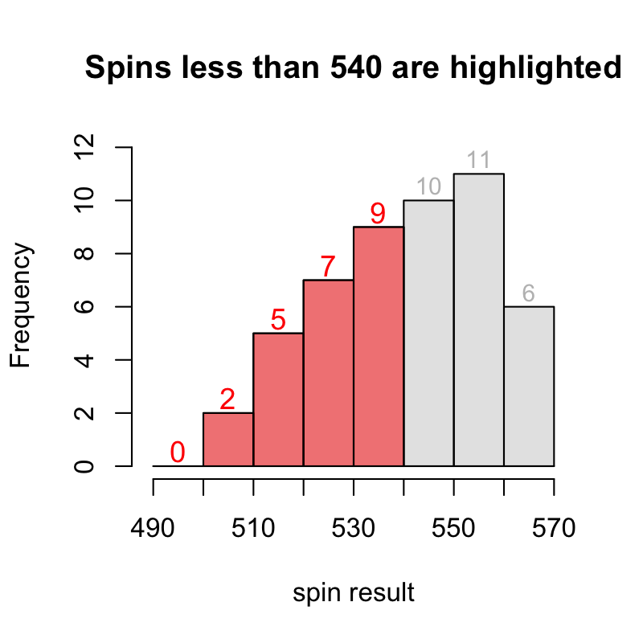

$$0+2+5+7+9=23$$

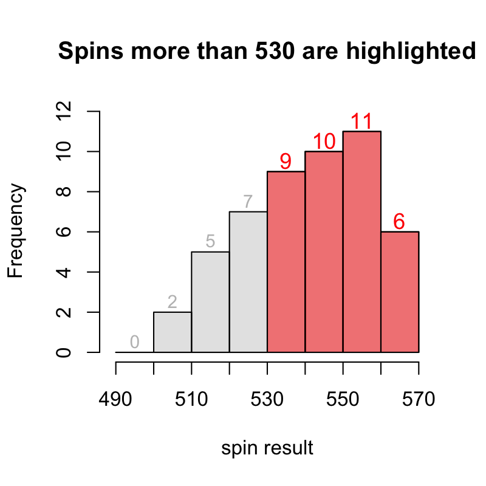

$$9+10+11+6=36$$

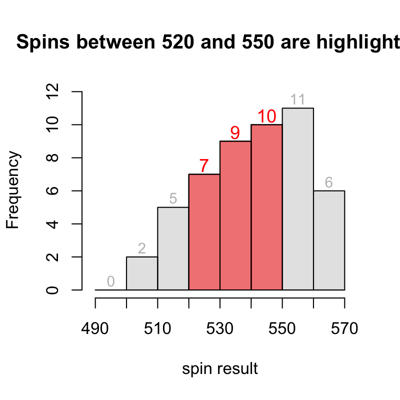

$$7+9+10=26$$

*S-ID.A: Summarize, represent, and interpret data on a single count or measurement variable. Use calculators, spreadsheets, and other technology as appropriate.*

A spinner was made to model a [continuous triangular distribution](https://en.wikipedia.org/wiki/Triangular_distribution). It was spun 50 times; those locations are marked.

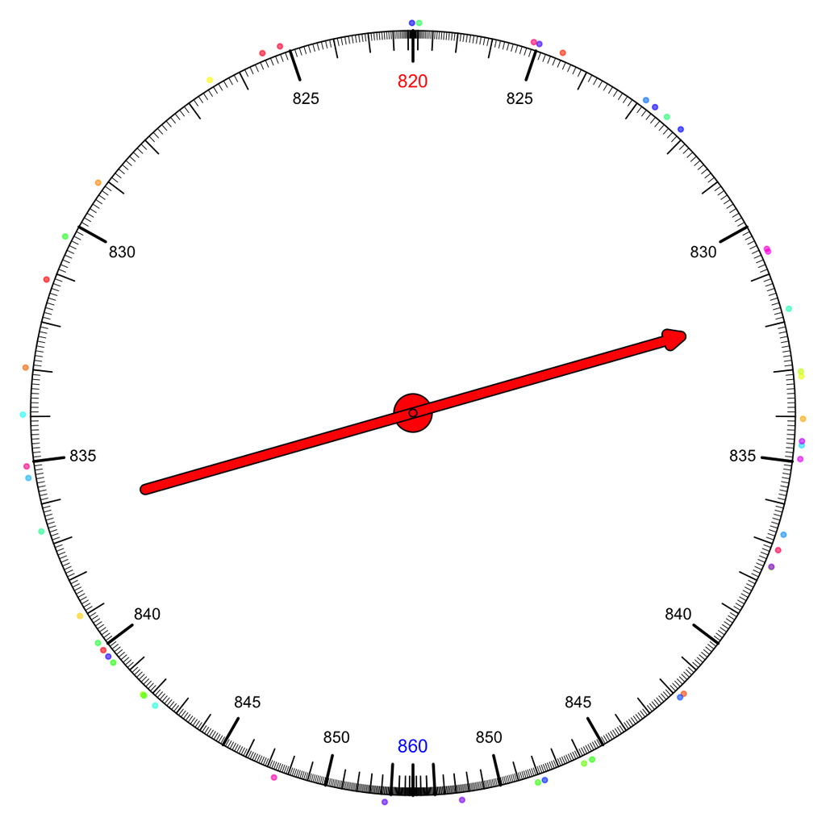

The name "triangular distribution" comes from the probability density curve.

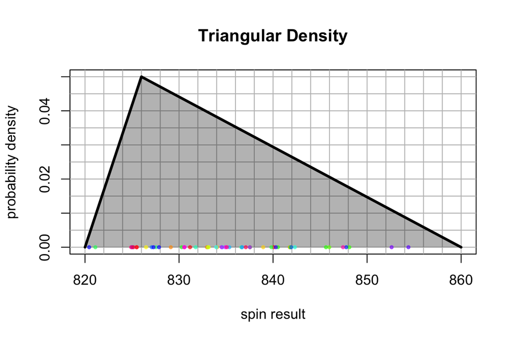

Notice that because the spinner is continuous, it generates data like 837.7099032 and 830.5338704. Of course, a human would probably round to the nearest tenth or so.

### Actual question

The 50 spins were used to generate a histogram.

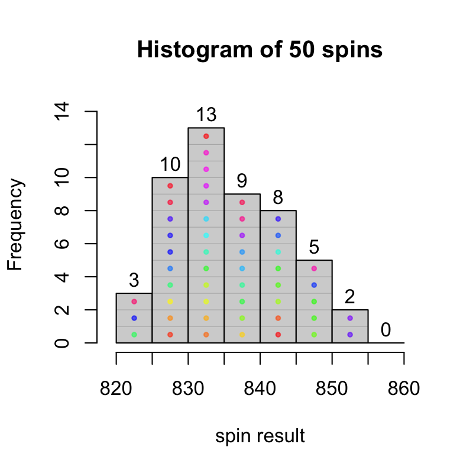

- How many spins were less than 835?
  - $\#(x<835) =$
- What proportion of spins were less than 835?
  - $\mathrm{proportion}(x<835) =$
- How many spins were more than 845?
  - $\#(x>845) =$
- What proportion of spins were more than 845?
  - $\mathrm{proportion}(x>845) =$
- How many spins were between 840 and 855?
  - $\#(840<x<855) =$
- What proportion of spins were between 840 and 855?
  - $\mathrm{proportion}(840<x<855) =$
- $\#(x<835) =$ 26
- $\mathrm{proportion}(x<835) = \frac{26}{50} =$ 0.52
- $\#(x>845) =$ 7
- $\mathrm{proportion}(x>845) = \frac{7}{50} =$ 0.14
- $\#(840<x<855) =$ 15
- $\mathrm{proportion}(840<x<855) = \frac{15}{50} =$ 0.3

You might find the following visualizations helpful.

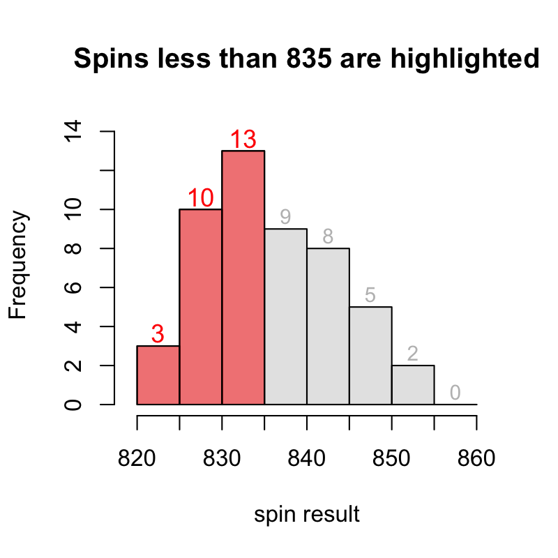

$$3+10+13=26$$

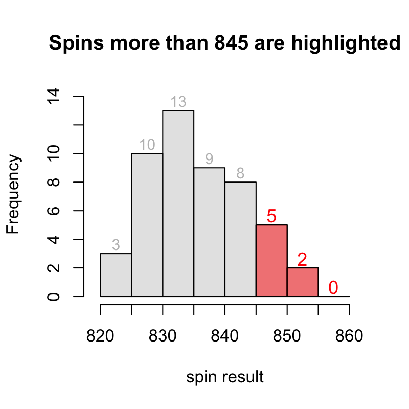

$$5+2+0=7$$

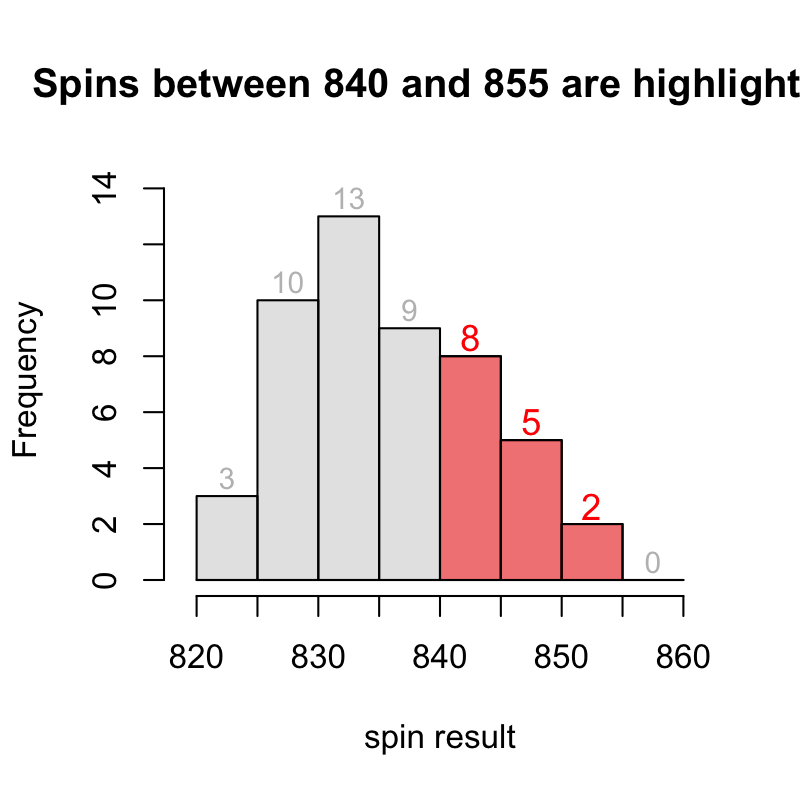

$$8+5+2=15$$

*S-ID.A: Summarize, represent, and interpret data on a single count or measurement variable. Use calculators, spreadsheets, and other technology as appropriate.*

A spinner was made to model a [continuous triangular distribution](https://en.wikipedia.org/wiki/Triangular_distribution). It was spun 50 times; those locations are marked.

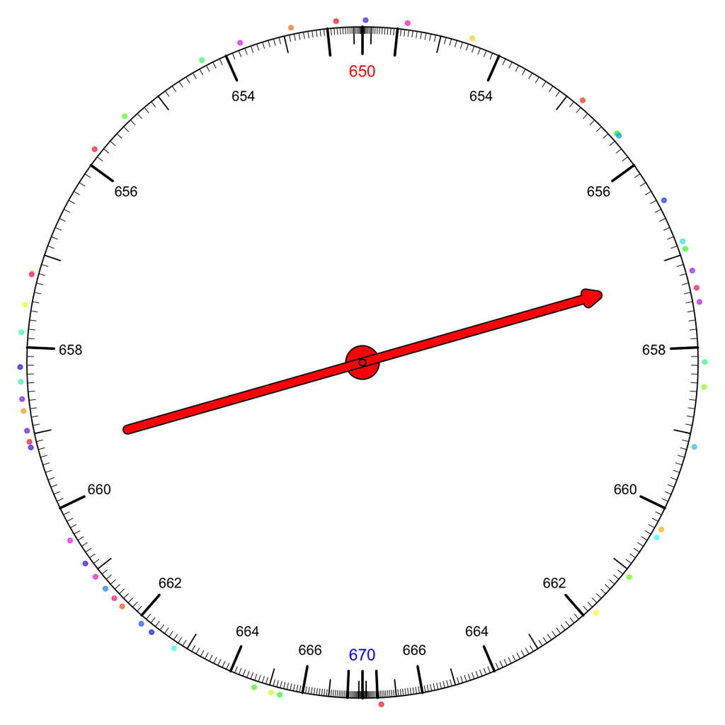

The name "triangular distribution" comes from the probability density curve.

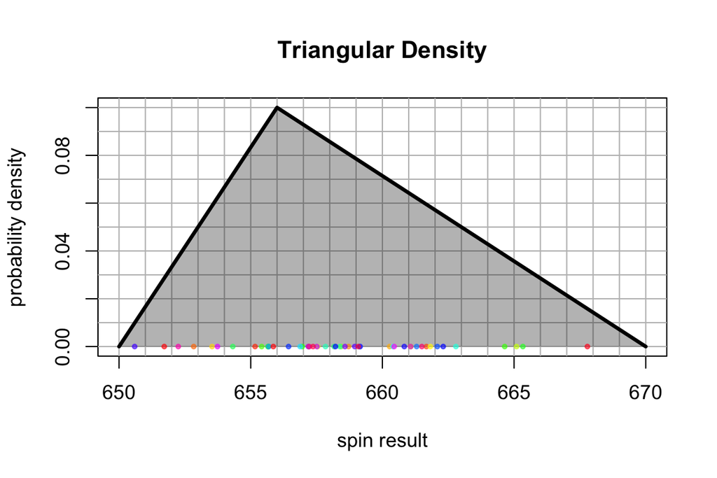

Notice that because the spinner is continuous, it generates data like 658.7537958 and 655.9226955. Of course, a human would probably round to the nearest tenth or so.

### Actual question

The 50 spins were used to generate a histogram.

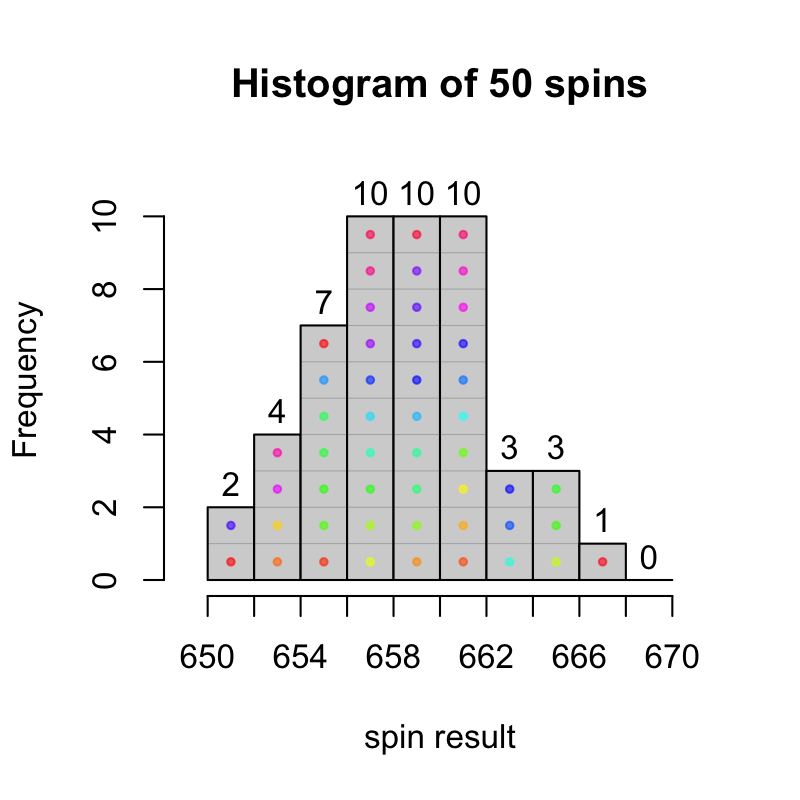

- How many spins were less than 656?
  - $\#(x<656) =$
- What proportion of spins were less than 656?
  - $\mathrm{proportion}(x<656) =$
- How many spins were more than 662?
  - $\#(x>662) =$
- What proportion of spins were more than 662?
  - $\mathrm{proportion}(x>662) =$
- How many spins were between 660 and 668?
  - $\#(660<x<668) =$
- What proportion of spins were between 660 and 668?
  - $\mathrm{proportion}(660<x<668) =$
- $\#(x<656) =$ 13
- $\mathrm{proportion}(x<656) = \frac{13}{50} =$ 0.26
- $\#(x>662) =$ 7
- $\mathrm{proportion}(x>662) = \frac{7}{50} =$ 0.14
- $\#(660<x<668) =$ 17
- $\mathrm{proportion}(660<x<668) = \frac{17}{50} =$ 0.34

You might find the following visualizations helpful.

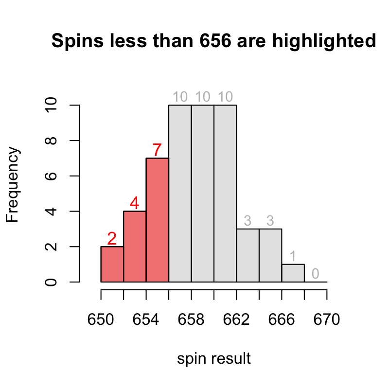

$$2+4+7=13$$

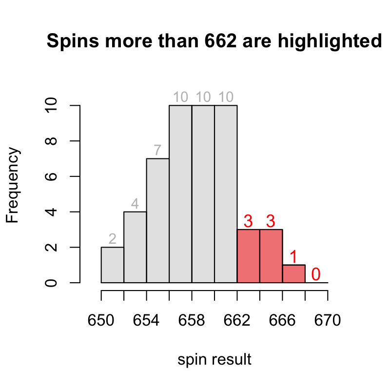

$$3+3+1+0=7$$

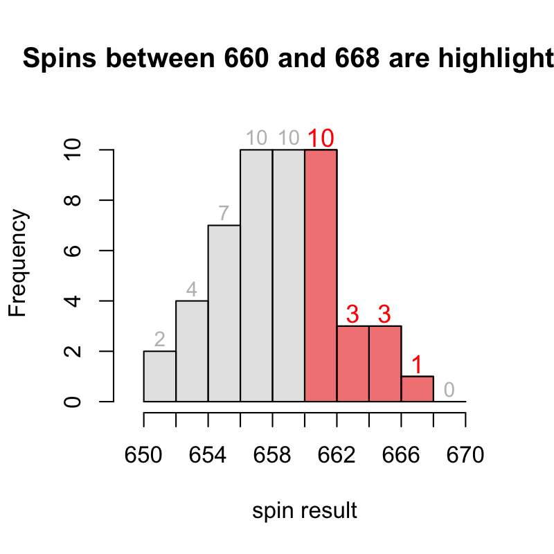

$$10+3+3+1=17$$

*S-ID.A: Summarize, represent, and interpret data on a single count or measurement variable. Use calculators, spreadsheets, and other technology as appropriate.*

A spinner was made to model a [continuous triangular distribution](https://en.wikipedia.org/wiki/Triangular_distribution). It was spun 50 times; those locations are marked.

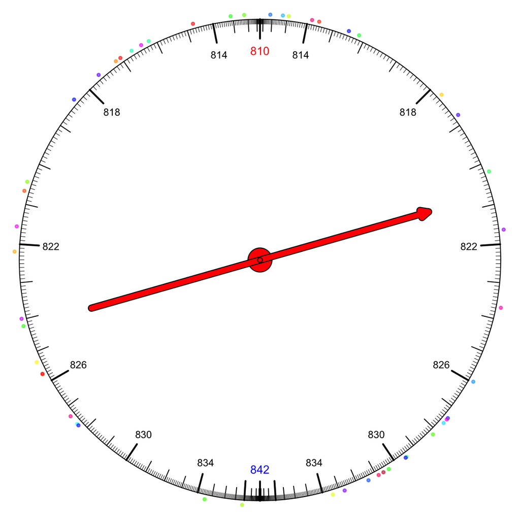

The name "triangular distribution" comes from the probability density curve.

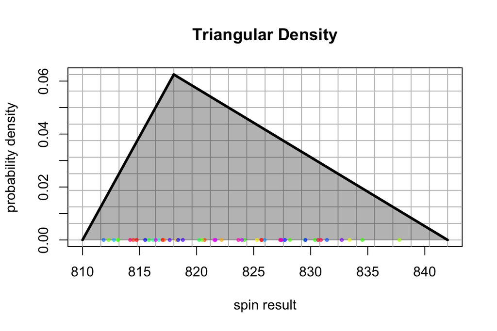

Notice that because the spinner is continuous, it generates data like 817.9949277 and 828.679101. Of course, a human would probably round to the nearest tenth or so.

### Actual question

The 50 spins were used to generate a histogram.

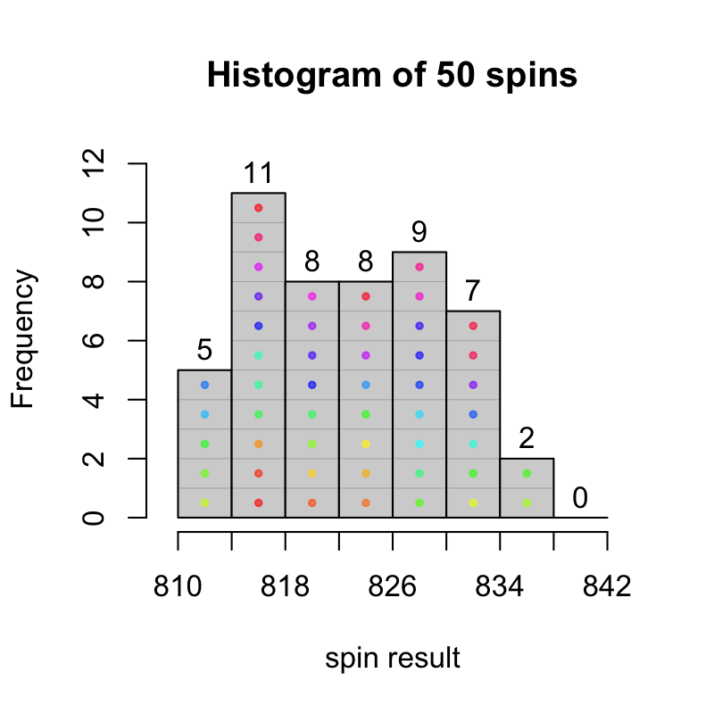

- How many spins were less than 822?
  - $\#(x<822) =$
- What proportion of spins were less than 822?
  - $\mathrm{proportion}(x<822) =$
- How many spins were more than 830?
  - $\#(x>830) =$
- What proportion of spins were more than 830?
  - $\mathrm{proportion}(x>830) =$
- How many spins were between 826 and 838?
  - $\#(826<x<838) =$
- What proportion of spins were between 826 and 838?
  - $\mathrm{proportion}(826<x<838) =$
- $\#(x<822) =$ 24
- $\mathrm{proportion}(x<822) = \frac{24}{50} =$ 0.48
- $\#(x>830) =$ 9
- $\mathrm{proportion}(x>830) = \frac{9}{50} =$ 0.18
- $\#(826<x<838) =$ 18
- $\mathrm{proportion}(826<x<838) = \frac{18}{50} =$ 0.36

You might find the following visualizations helpful.

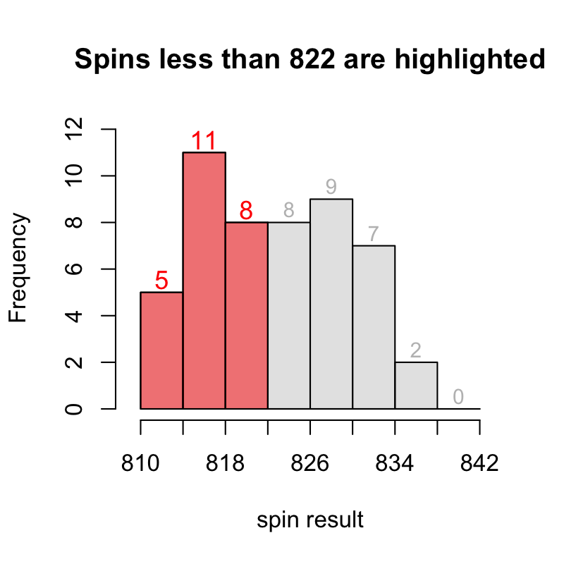

$$5+11+8=24$$

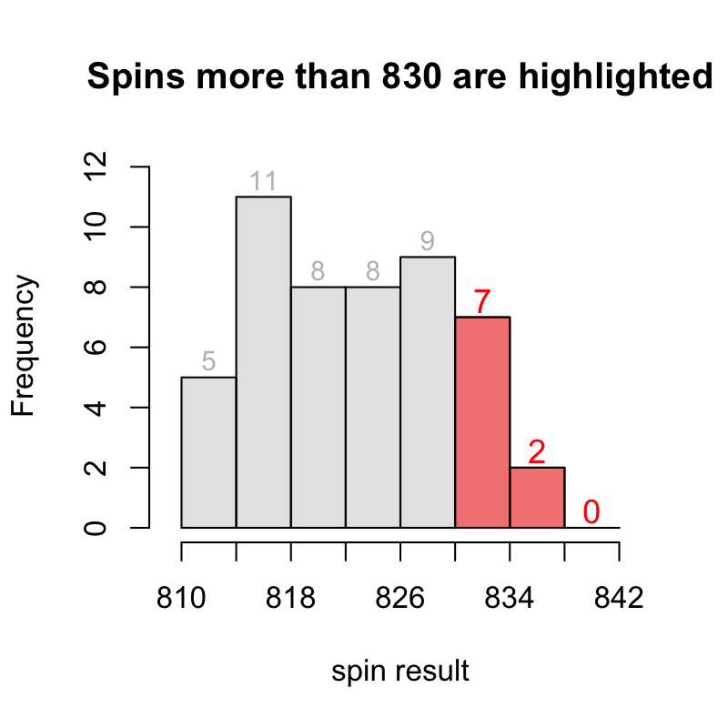

$$7+2+0=9$$

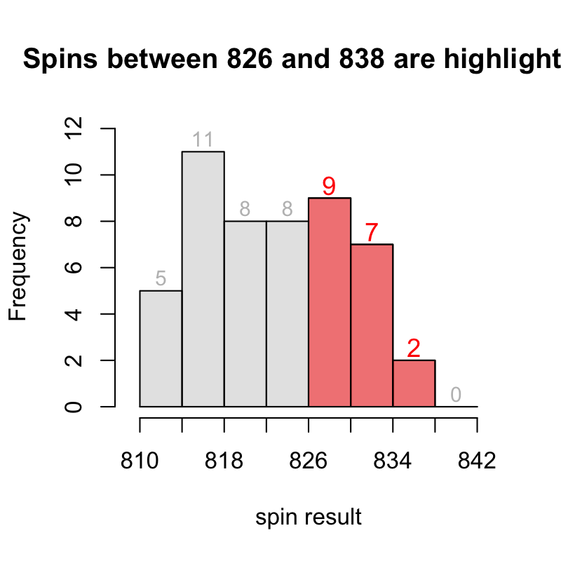

$$9+7+2=18$$

*S-ID.A: Summarize, represent, and interpret data on a single count or measurement variable. Use calculators, spreadsheets, and other technology as appropriate.*

A spinner was made to model a [continuous triangular distribution](https://en.wikipedia.org/wiki/Triangular_distribution). It was spun 50 times; those locations are marked.

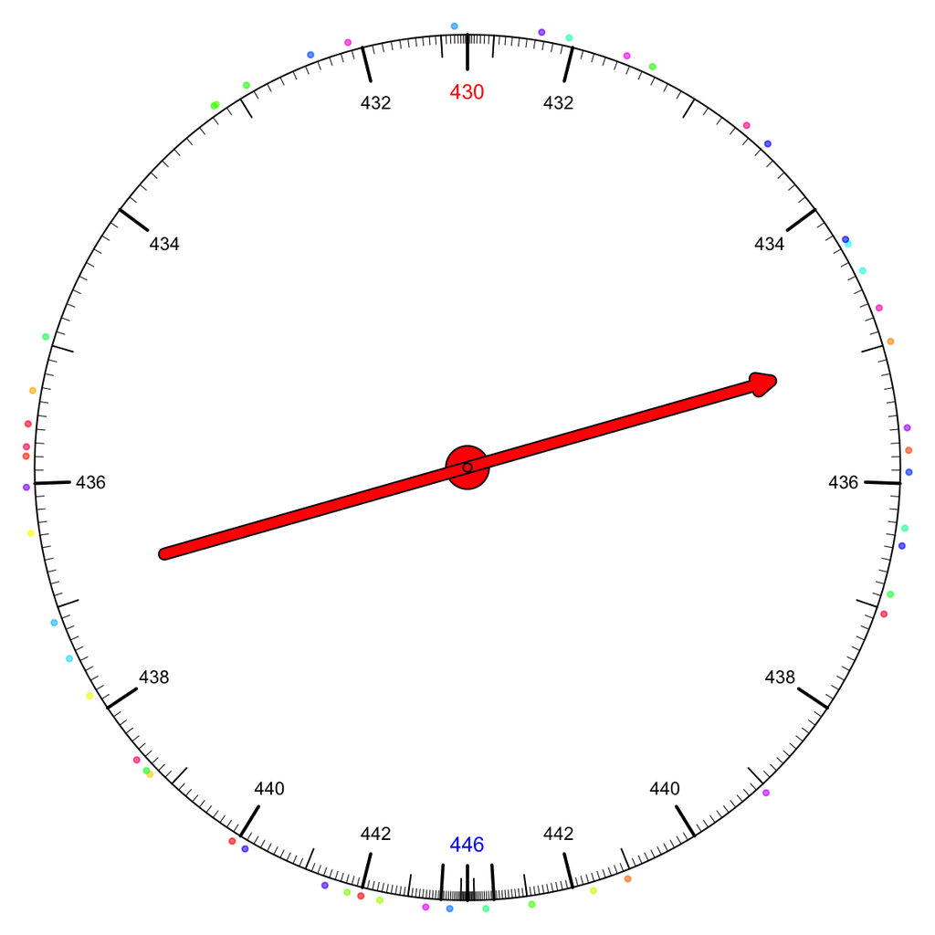

The name "triangular distribution" comes from the probability density curve.

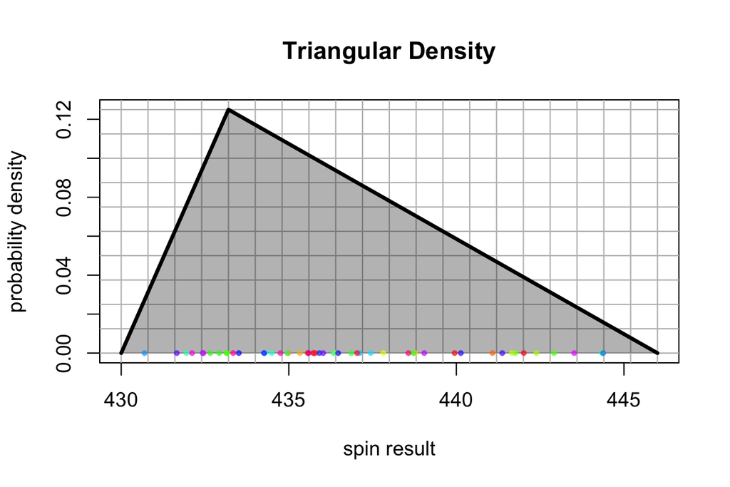

Notice that because the spinner is continuous, it generates data like 437.6962734 and 432.7986962. Of course, a human would probably round to the nearest tenth or so.

### Actual question

The 50 spins were used to generate a histogram.

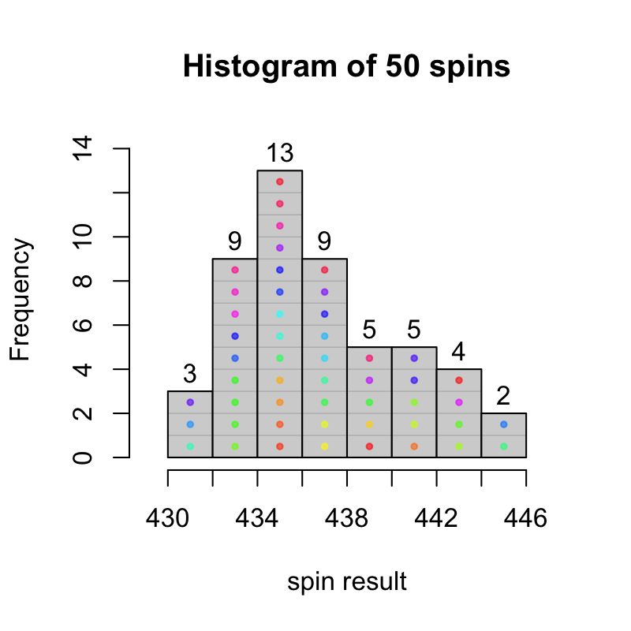

- How many spins were less than 436?
  - $\#(x<436) =$
- What proportion of spins were less than 436?
  - $\mathrm{proportion}(x<436) =$
- How many spins were more than 440?
  - $\#(x>440) =$
- What proportion of spins were more than 440?
  - $\mathrm{proportion}(x>440) =$
- How many spins were between 434 and 442?
  - $\#(434<x<442) =$
- What proportion of spins were between 434 and 442?
  - $\mathrm{proportion}(434<x<442) =$
- $\#(x<436) =$ 25
- $\mathrm{proportion}(x<436) = \frac{25}{50} =$ 0.5
- $\#(x>440) =$ 11
- $\mathrm{proportion}(x>440) = \frac{11}{50} =$ 0.22
- $\#(434<x<442) =$ 32
- $\mathrm{proportion}(434<x<442) = \frac{32}{50} =$ 0.64

You might find the following visualizations helpful.

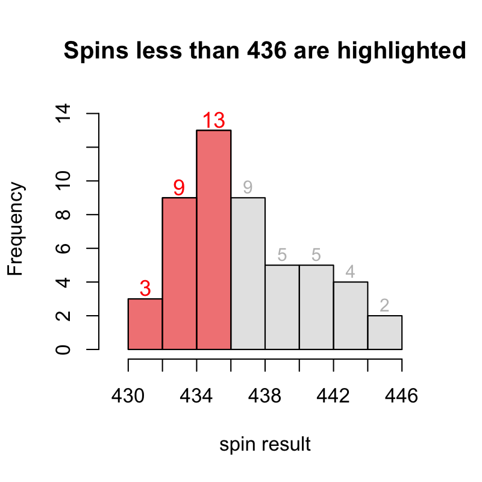

$$3+9+13=25$$

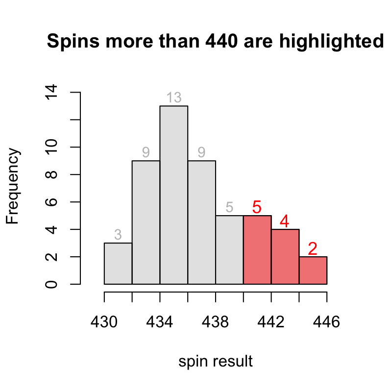

$$5+4+2=11$$

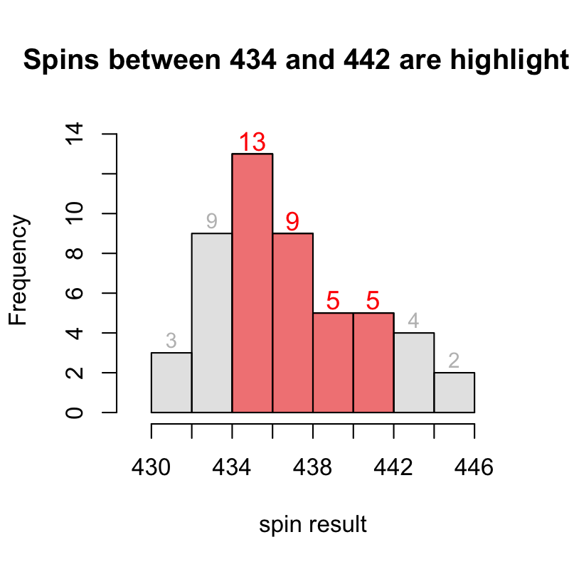

$$13+9+5+5=32$$

*S-ID.A: Summarize, represent, and interpret data on a single count or measurement variable. Use calculators, spreadsheets, and other technology as appropriate.*

A spinner was made to model a [continuous triangular distribution](https://en.wikipedia.org/wiki/Triangular_distribution). It was spun 50 times; those locations are marked.

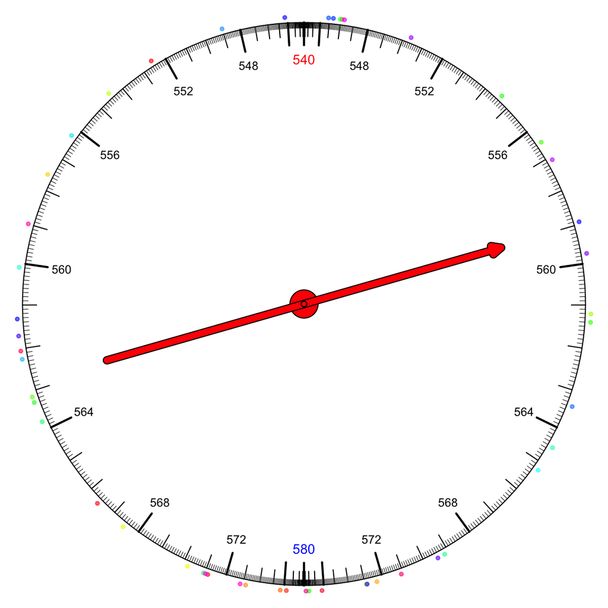

The name "triangular distribution" comes from the probability density curve.

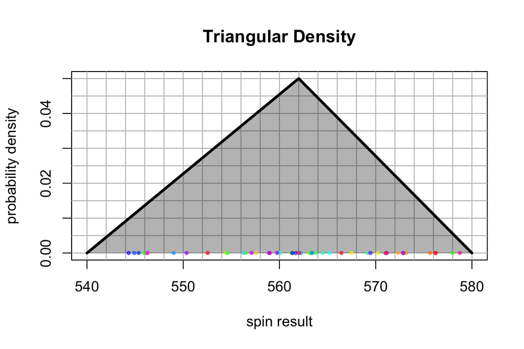

Notice that because the spinner is continuous, it generates data like 561.9606031 and 553.782756. Of course, a human would probably round to the nearest tenth or so.

### Actual question

The 50 spins were used to generate a histogram.

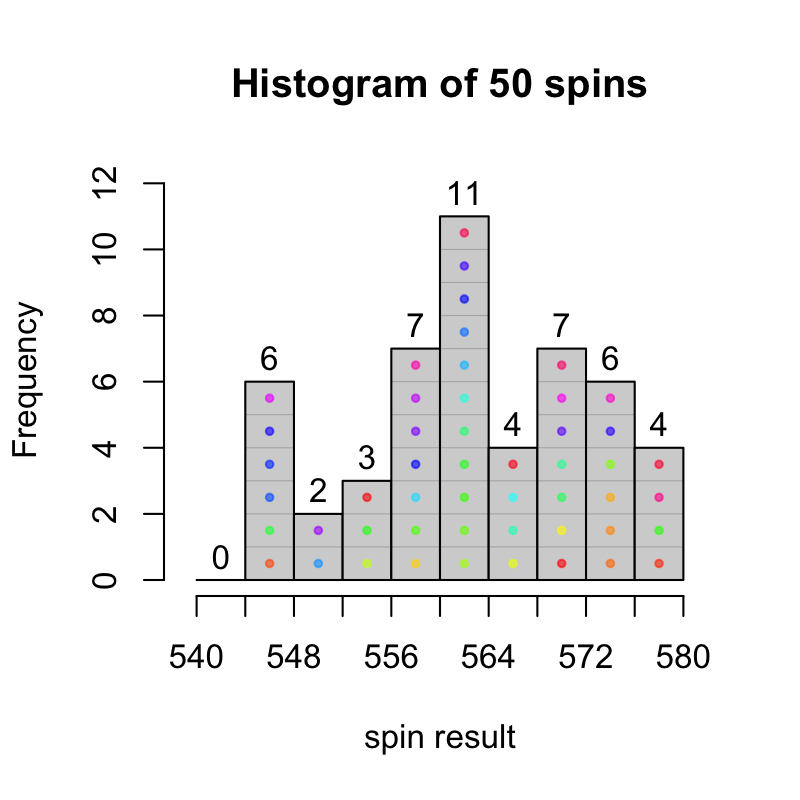

- How many spins were less than 560?
  - $\#(x<560) =$
- What proportion of spins were less than 560?
  - $\mathrm{proportion}(x<560) =$
- How many spins were more than 556?
  - $\#(x>556) =$
- What proportion of spins were more than 556?
  - $\mathrm{proportion}(x>556) =$
- How many spins were between 552 and 576?
  - $\#(552<x<576) =$
- What proportion of spins were between 552 and 576?
  - $\mathrm{proportion}(552<x<576) =$
- $\#(x<560) =$ 18
- $\mathrm{proportion}(x<560) = \frac{18}{50} =$ 0.36
- $\#(x>556) =$ 39
- $\mathrm{proportion}(x>556) = \frac{39}{50} =$ 0.78
- $\#(552<x<576) =$ 38
- $\mathrm{proportion}(552<x<576) = \frac{38}{50} =$ 0.76

You might find the following visualizations helpful.

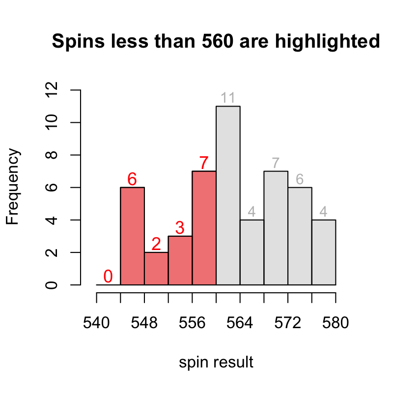

$$0+6+2+3+7=18$$

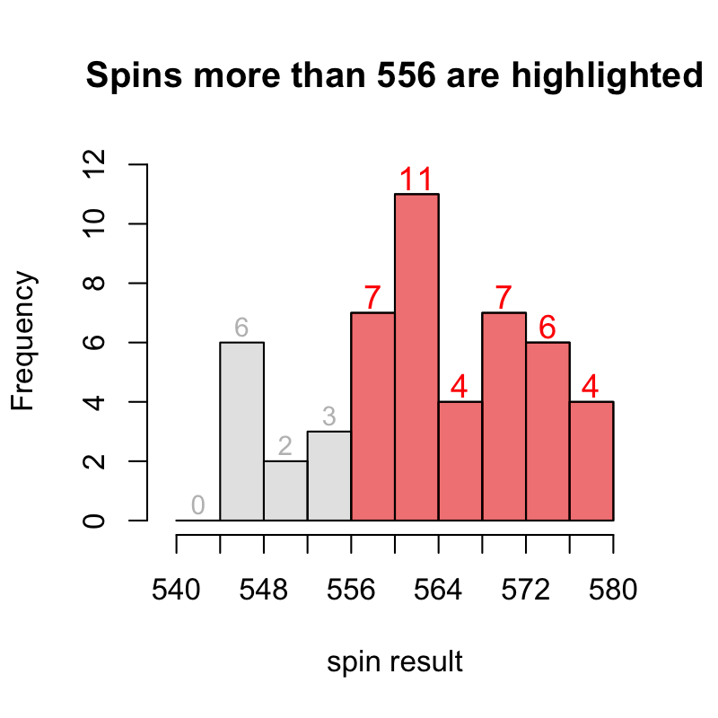

$$7+11+4+7+6+4=39$$

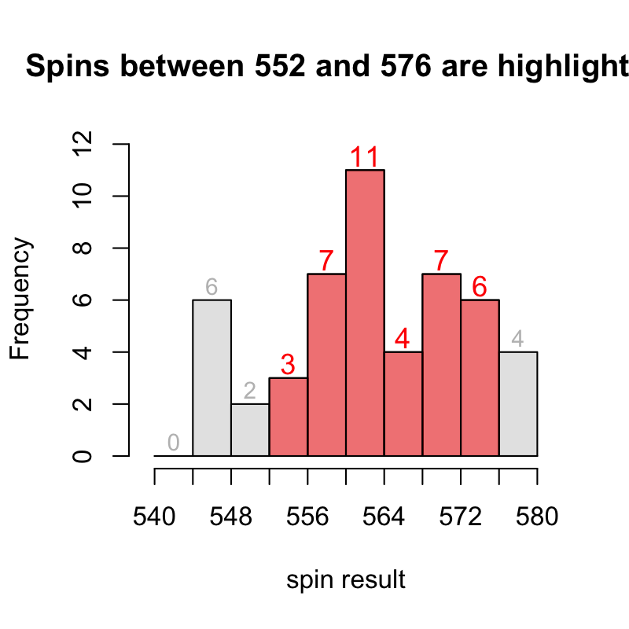

$$3+7+11+4+7+6=38$$

*S-ID.A: Summarize, represent, and interpret data on a single count or measurement variable. Use calculators, spreadsheets, and other technology as appropriate.*

A spinner was made to model a [continuous triangular distribution](https://en.wikipedia.org/wiki/Triangular_distribution). It was spun 50 times; those locations are marked.

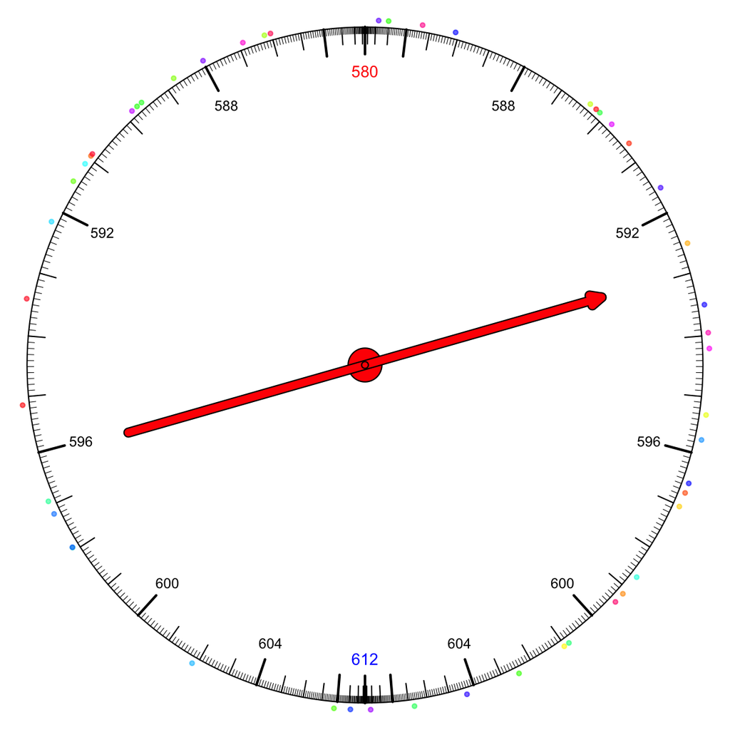

The name "triangular distribution" comes from the probability density curve.

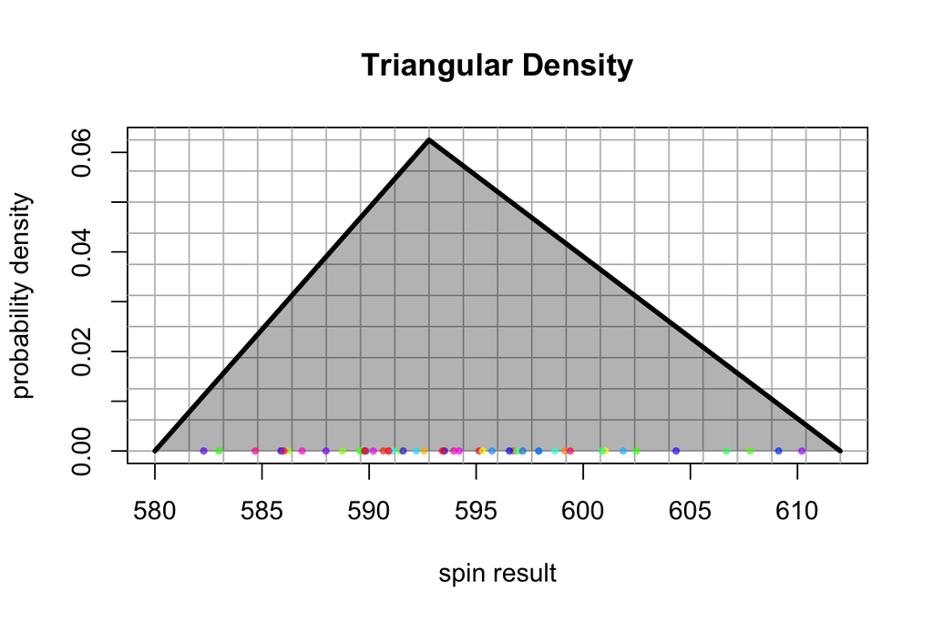

Notice that because the spinner is continuous, it generates data like 595.6673618 and 593.7017851. Of course, a human would probably round to the nearest tenth or so.